# Molecular Marker Assisted Plant Breeding

GWAS Models and Methods

Felipe Ferrão

University of Florida

**Objectives:**

- 60 minutes of hands-on
- Introduction to GWAS models
- Running models in R

**Extra information**

- [HOS 6236 – Website](https://lfelipe-ferrao.github.io/class/mas/)
- About the [author](https://lfelipe-ferrao.github.io/)
- About the [UF/IFAS Plant Breeding](https://programs.ifas.ufl.edu/plant-breeding/)

# Introduction

Genome-wide association studies (GWAS) have become a foundational tool for linking genetic variants to complex traits across diverse populations. Unlike classical QTL mapping, which often utilizes controlled biparental crosses with limited allelic diversity, GWAS harnesses natural variation, offering higher resolution and broader applicability. However, this added flexibility comes with statistical challenges: population structure, cryptic relatedness, and background polygenic effects can introduce spurious associations, making it difficult to distinguish causal variants from confounding signals.

In my view, the literature is evolving in two main directions with regard to software and methodologies, focusing on two closely related areas:

- Modeling strategies
- Algorithm development

## Modeling Strategies

Over time, GWAS methodology has evolved from simple single-marker regression to more sophisticated frameworks all designed to control false positives and improve power for detecting true causal loci. Below, we classified the methods into four main categories:

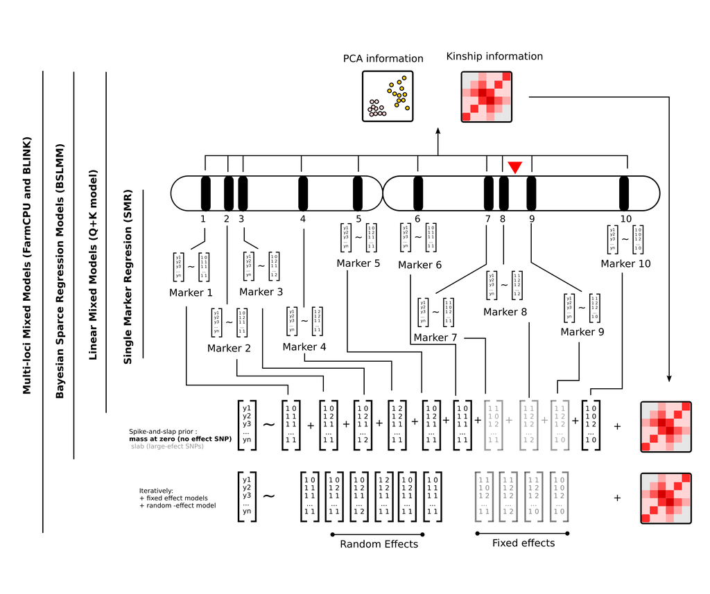

GWAS methods classified in four main categories ranging from mkodels that account for a single marker per time, inclugin methods to control for population structure, and the use of multiple markers (loci) at the same time considering different approaches

**Notation Key**

- **y**: phenotype vector
- **X**: genotype matrix (individuals × SNPs)
- **xₖ**: genotype vector at marker *k*
- **β, βₖ**: fixed SNP effect(s)
- **Z**: incidence matrix for random effects
- **u**: polygenic effect (random)
- **K**: kinship matrix
- **ε**: residual error
- **g(x)**: nonlinear mapping (e.g., neural net)

**1. Simple Linear Regression (Single SNP)**
$$y = \mu + x_k \beta_k +
\varepsilon$$

- **Assumes**: no structure, no relatedness
- **Methods/Tools**: PLINK, GenABEL, `lm`function in R
- Purcell et al., 2007 ([PLoS Genet](https://doi.org/10.1371/journal.pgen.0030190))

**3. Linear Mixed Model (LMM)**

$$y = \mu + \sum_{i=1}^{m} PC_i
\alpha_i+ x_k \beta_k + u + \varepsilon, \quad \text{with } u \sim
\mathcal{N}(0, \sigma_g^2 K)$$

- **Adds**: Random polygenic effect `u` with variance from **kinship matrix (K)** and information from PCA analysis.
- **Tools**: GEMMA, EMMAX, FaST-LMM, GCTA
- Kang et al., 2008 ([Nat Genet](https://doi.org/10.1038/ng.548))
- Zhou & Stephens, 2012 ([Nat Genet](https://doi.org/10.1038/ng.2310))
- Price et al., 2006 ([Nat Genet](https://doi.org/10.1038/ng1847))

**3. Bayesian Sparse Linear Mixed Model (BSLMM)**

$$y = \mu + X \beta + u + \varepsilon,
\quad \beta_j \sim \pi \cdot \mathcal{N}(0, \sigma_\beta^2) + (1 - \pi)
\cdot \delta_0$$
- **Adds**: Sparse prior on effect sizes (most effects = 0) - **Tools**: GEMMA (BSLMM), BayesR, BGLR - Zhou et al., 2013 ([PLoS Genet](https://doi.org/10.1371/journal.pgen.1003264))

**4. Multi-locus Mixed Model (MLMM, FarmCPU, BLINK)**

$$y = \mu + \sum_{j=1}^m x_j \beta_j + u +
\varepsilon, \quad u \sim \mathcal{N}(0, \sigma_g^2 K)$$

Iteratively fits:

1. Fixed-effect model:

   $$y = \mu + \sum x_j \beta_j + \varepsilon$$
2. Then updates random-effect model:

   $$y = \mu + u + \varepsilon, \quad u \sim \mathcal{N}(0, \sigma_g^2 K)$$
- **Tools**: GAPIT, rMVP
- **Goal**: Reduce confounding from large-effect loci in polygenic background
- Segura et al., 2012 ([Plant Physiol](https://doi.org/10.1104/pp.112.212134))
- Liu et al., 2016 ([Sci Rep](https://doi.org/10.1038/srep33444))
- Huang et al., 2018 ([GigaScience](https://doi.org/10.1093/gigascience/giy154))

**Summary Table**

| Method | Model Form | Key Additions | Tool(s) |
| --- | --- | --- | --- |
| Simple GWAS | $y = \mu + x_k \beta_k + \varepsilon$ | None | PLINK, GenABEL |
| PCA GWAS | $y = \mu + x_k \beta_k + \sum PC_i \alpha_i + \varepsilon$ | Population structure (PCs) | EIGENSTRAT, PLINK |
| LMM | $y = \mu + x_k \beta_k + u + \varepsilon$ | Relatedness (kinship matrix) | GEMMA, EMMAX, GCTA |
| BSLMM | $y = \mu + X\beta + u + \varepsilon$ | Sparse β, polygenicity | GEMMA, BayesR |
| MLMM/FarmCPU | $y = \mu + \sum x_j \beta_j + u + \varepsilon$ | Multi-locus + background correction | GAPIT, rMVP |

### What is the Best Model for GWAS?

There is no single “best” model for GWAS — the optimal choice often depends on the genetic architecture of the trait, the structure of the population, and the characteristics of the dataset.

In my experience, it’s clear that when a marker is strongly associated with a QTL and has a clear, high-effect signal, most GWAS models — from simple linear regression to more complex mixed models — will be able to detect it (look the example below). In these cases, the primary distinction lies in how well models control for **spurious associations**, particularly those caused by **population structure** or **relatedness**. Models that go beyond single-marker regression tend to handle these issues more robustly.

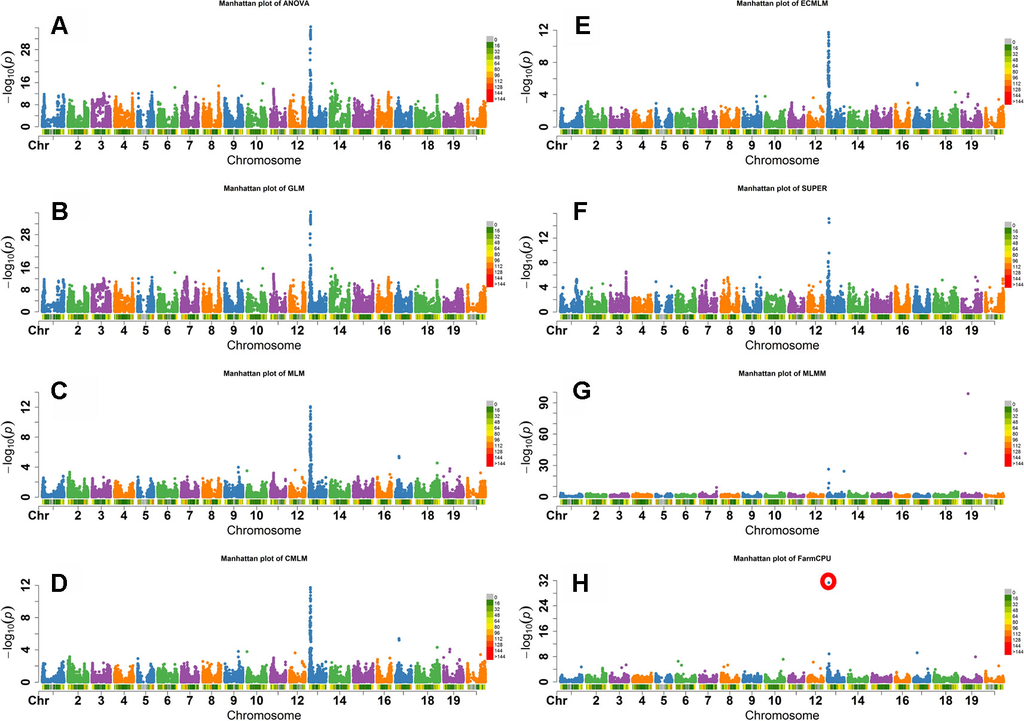

However, challenges emerge when dealing with **small-effect loci** — a more realistic scenario in many complex traits. Detecting these minor-effect variants is difficult due to several factors, including:

- **Low minor allele frequency (MAF)**: Rare variants have limited power unless sample sizes are very large.
- **Small population size**: Reduced power and increased sampling noise.
- **Data artifacts**: Batch effects, genotyping errors, and imputation inaccuracies can introduce false positives or obscure real signals.
- **Confounding variables**: Population structure, cryptic relatedness, and environmental covariates may bias associations if not properly controlled.

This is where different GWAS models may start producing divergent results. Mixed models (e.g., LMMs, BSLMM) incorporate kinship matrices to adjust for background polygenicity and relatedness, while multi-locus methods like FarmCPU or BLINK iteratively control for large-effect loci to reduce confounding. Bayesian methods offer improved modeling of uncertainty and sparsity but can be computationally demanding.

Given these complexities, my general recomendation is to not rely on a single GWAS method. Instead:

- **Run multiple models** (e.g., linear regression + LMM + multi-locus + Bayesian) to identify consistent signals.
- **Compare outputs** to assess the robustness of your candidate associations.
- **Consult previous literature** to validate if the same regions have been reported or biologically linked to the trait.
- **Incorporate complementary evidence** , such as: transcriptomic data, functional annotations (e.g., gene ontologies, known pathways(; other populations or mapping panels and experimental validation when feasible

This integrative approach increases confidence in your candidate loci and helps prioritize markers that are both statistically supported and biologically plausible.

## Algorithm development

A nice perspective about algorithm development was presented by [Huang et al., 2019](https://academic.oup.com/gigascience/article/8/2/giy154/5238723?login=true), who divided the computational advantages into five main milestone:

### Efficient mixed model association (EMMA)

Here, we will focus on describing the EMMA method. Why ? Because it has historical importance and also it is grounded on the use of mixed models applied to GWAS analysis. All the other computational methods are derivations (or approximations) of this method that is called an exact method.

Let’s start defining a mixed model equation in the context of GWAS:

$$\mathbf{y} =
\mathbf{X}\boldsymbol{\beta} + \mathbf{Z} \mathbf{u} +
\boldsymbol{\varepsilon}$$

Where:

- y : Response (phenotypes)
- X: Fixed-effects design matrix
- $\beta$: Fixed effects (marker effects)
- Z: Random-effects design matrix
- u: Random effects, or the polygenic term, distributed as $\mathbf{u} \sim \mathcal{N}(0, \sigma_g^2 \mathbf{G})$, where **G** is the genomic relationship/kinship matrix.
- e: Residual errors, where $\boldsymbol{\varepsilon} \sim \mathcal{N}(0, \sigma_e^2 \mathbf{I})$

Hence, the marginal distribution of ( ) is:

$$\mathbf{y} \sim
\mathcal{N}(\mathbf{X}\boldsymbol{\beta}, \mathbf{V})
\quad \text{with} \quad
\mathbf{V} = \mathbf{Z} \mathbf{G} \mathbf{Z}^\top \sigma_g^2 +
\sigma_e^2 \mathbf{I}$$

If we include it in the Henderson’s equation, we can estimate the fixed effects and predict the random effects all int he same framework using the follow group of equations:

$$\begin{bmatrix}
\mathbf{X}^\top \mathbf{R}^{-1} \mathbf{X} & \mathbf{X}^\top
\mathbf{R}^{-1} \mathbf{Z} \\
\mathbf{Z}^\top \mathbf{R}^{-1} \mathbf{X} & \mathbf{Z}^\top
\mathbf{R}^{-1} \mathbf{Z} + \mathbf{G}^{-1}
\end{bmatrix}
\begin{bmatrix}
\hat{\boldsymbol{\beta}} \\
\hat{\mathbf{u}}
\end{bmatrix}
=
\begin{bmatrix}
\mathbf{X}^\top \mathbf{R}^{-1} \mathbf{y} \\
\mathbf{Z}^\top \mathbf{R}^{-1} \mathbf{y}
\end{bmatrix}$$

Where:

$$\hat{\boldsymbol{\beta}} =
(\mathbf{X}^\top \mathbf{V}^{-1} \mathbf{X})^{-1} \mathbf{X}^\top
\mathbf{V}^{-1} \mathbf{y}$$
$$\hat{\mathbf{u}} = \sigma_g^2 \mathbf{G}
\mathbf{Z}^\top \mathbf{V}^{-1} (\mathbf{y} - \mathbf{X}
\hat{\boldsymbol{\beta}})$$
**Why this is so important ?**

Do not get overwhelmed with the equations and the matrix notation. The most important point is that exist a **mutual dependency between fixed and random effects**, or, in another words, you need estimates of variance components (from random effects) to estimate fixed effects, and you need fixed effects to estimate random effects.

When translated into the GWAS context, estimating the marker effects ($\hat{\beta}$)requires knowledge of the covariance matrix, which in turn depends on the variance components. Now, imagine repeating this process for every single SNP — with, say, 50,000 SNPs, estimating variance components and inverting the **V** matrix for each one becomes computationally prohibitive.

**EMMA was proposed to solve it efficiently by:**

1. Estimate kinship matrix ( $\mathbf{K}$ )
2. Eigen-decompose ( $\mathbf{K} ): ( \mathbf{K} = \mathbf{U} \mathbf{D} \mathbf{U}^\top$ )
3. Transform data: ( $\mathbf{y}^*$, $\mathbf{X}^*$ )
4. Estimate ( $\lambda$ ) (and ( $\sigma_g^2$ ) using REML:

$$\log L_R(\lambda) = -\frac{1}{2} \left[ \log |\mathbf{V}| +
\log|\mathbf{X}^\top \mathbf{V}^{-1} \mathbf{X}| + (\mathbf{y} -
\mathbf{X}\boldsymbol{\beta})^\top \mathbf{V}^{-1} (\mathbf{y} -
\mathbf{X}\boldsymbol{\beta}) + \text{const} \right]$$

5. For each SNP: add to ( $\mathbf{X}$ ), re-use variance estimates, test ( $H_0: \beta$ = 0$ )
6. Output p-values or effect sizes

# Hands-on

In this class, we will focus on running and comparing different GWAS methods using distinct software tools.

**What we will NOT cover during this class?**

- We will not include simple regression models at this stage, as the next class will specifically address the importance of accounting for population structure to control for spurious associations.
- We will also not introduce diagnostic tools, such as QQ plots, to evaluate model performance.
- We will not discuss about potential software and methods to incorporate population structure information, since it will be covered in the next section.
- The use of Bayesian Sparse Linear Mixed Model (BSLMM) will be covered in a separate class, as it involves software outside of the R ecosystem.

**What we will cover?**

- Fit a simple phenotypic model to adjust our phenotypic records
- Apply and interpret results from standard GWAS models
- Explore the outputs
- Compare methods based on their performance and assumptions.

## Coffee data set

- [Ferrão et al., 2023](https://acsess.onlinelibrary.wiley.com/doi/full/10.1002/tpg2.20321)
- Genotyping-by-sequencing: 58k markers
- Population size: 222 genotypes
- Randomized complete block design with three replications
- Four consecutive harvest-production years (2008–2011)

## `GWASpoly`

- Software that implements the Q+K model (LMM)
- Can be used for multiple ploidy levels
- Functions for ploting and filtering the data
- Fast implementation
- [Github page](https://github.com/jendelman/GWASpoly)

### Reading the data

```r
# Load required libraries
library(openxlsx)
library(dplyr)
library(lme4)
library(emmeans)
library(purrr)
library(GWASpoly)

# Genomic information
load("/home/felipe/Dropbox (UFL)/classes/Molecular_Breeding/class5_GWAS/GWASmodels/coffee_example_222ind_58k.Rdata")
M[1:5,1:5]
```

```
##     snp.name chr.name pos.name INTERM_104 INTERM_105
## 1 1_10023292        1 10023292          0          0
## 2 1_10023306        1 10023306          0          0
## 3 1_10023307        1 10023307          0          0
## 4   1_101547        1   101547          0         -1
## 5   1_101623        1   101623         -1         NA
```

```r
# Load phenotype data
pheno <- read.xlsx("/home/felipe/Dropbox (UFL)/classes/Molecular_Breeding/class5_GWAS/GWASmodels/coffee_phenotype.xlsx")

# Create unique ID and filter for IDs present in M
pheno <- pheno %>%
  mutate(id = paste(pop, trat, sep = "_"),
         yield =`BeanWeight(g)`/5 ) %>% # put in the original scale, kg per plant
  filter(id %in% colnames(M))
```

### Phenotypic Data

- Trait 1: yield data, in Kg per plant
- Trait 2: ratio between the raw harvested fruit (coffee cherries) and the processed, dried, hulled beans — ready for roasting (green coffee). The ratio indicates how much of the harvested fruit ends up as usable coffee.
- Trait 3: bean residual (RES). In coffee grading, beans are passed through a series of sieves with different hole sizes. Larger beans remain on top of larger sieves (e.g., sieve 18). Smaller beans fall through to lower sieves or the bottom (residual). The fraction of beans retained at the bottom, i.e., beans too small to be retained by any standard sieve size. A high sieve residual implies a higher proportion of small or defective beans, which are considered lower quality.

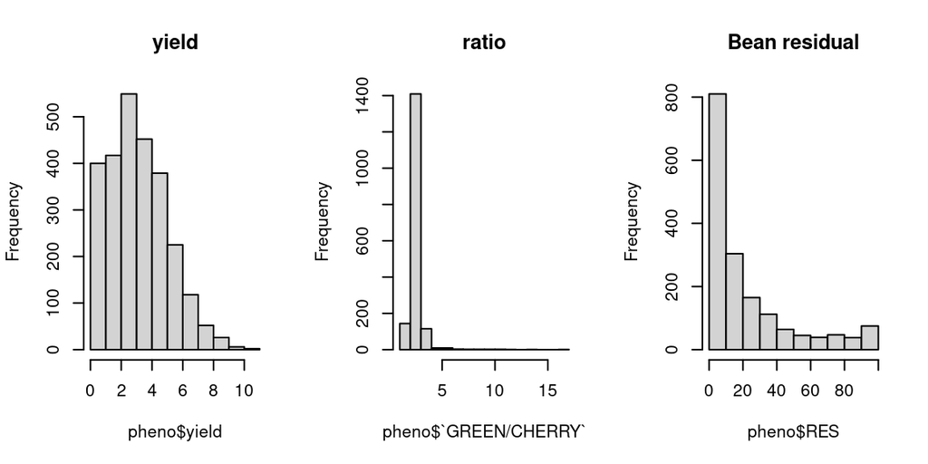

```r
par(mfrow=c(1,3))
hist(pheno$yield, main="yield")
hist(pheno$`GREEN/CHERRY`, main="ratio")
hist(pheno$RES, main="Bean residual")
```

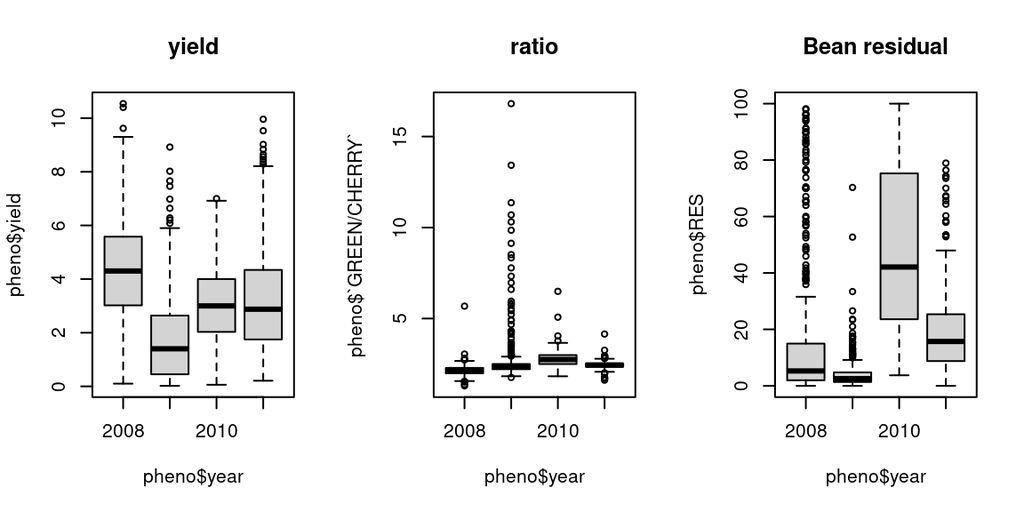

```r
# Factorize categorical variables
pheno <- pheno %>%  mutate(across(c(id, block, year), as.factor))

# Distributiona cross the years

par(mfrow=c(1,3))
boxplot(pheno$yield~pheno$year, main="yield")
boxplot(pheno$`GREEN/CHERRY`~pheno$year, main="ratio")
boxplot(pheno$RES~pheno$year, main="Bean residual")
```

**Phenotypic Model**

$$y_{ijk} = \mu + \text{block}_i + geno_j
+ year_k + (geno\times year)_{jk} + \varepsilon_{ijk}$$

Where:

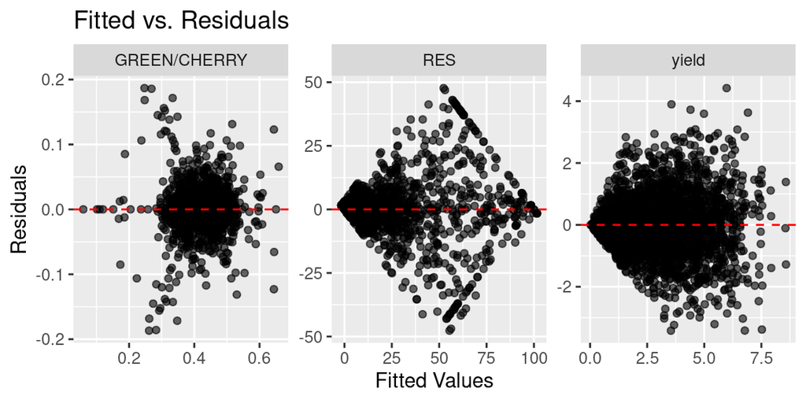

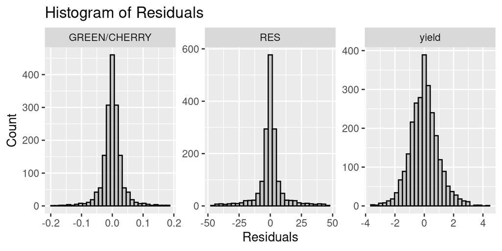

```r
# Fit linear models for multiple traits
traits <- c("yield", "GREEN/CHERRY", "RES")
models <- setNames(
  map(traits, ~ lm(as.formula(paste(.x, "~ block + id * year")), data = pheno)),
  traits
)
```

**Questions**

- Are the residuals good ?
- Why some trends in the `RES`trait ?

**Computing the marginal adjusted means for the phenotypic values**

- We can compute the BLUEs associated to each trait
- In another words, we can compute the “phenotypic value” of each individual, per trait, after correcting for the `year` and `block` effects.
- Package `emmeans`

$$\hat{\mu}*j^{(t)} = \mathbb{E}\left[ \hat{y}*{ijk}^{(t)} \mid
\text{geno} = j \right] = \hat{\mu}^{(t)} + \hat{\text{geno}}_j^{(t)} +
\mathbb{E}\left[ \hat{\text{year}}*k^{(t)} + \hat{(\text{geno} \times
\text{year})}*{jk}^{(t)} \right]$$

```r
# Get estimated marginal means for treatment
emms <- map(models, ~ emmeans(.x, ~ id))

# Combine emmeans into a summary dataframe
emm_summary <- map_dfc(emms, ~ summary(.x)$emmean)
colnames(emm_summary) <- traits

# Reshape emm_summary to long format
emm_long <- emm_summary %>%
  pivot_longer(
    cols = everything(),
    names_to = "Trait",
    values_to = "Emmean"
  )

# Pheno and geno in the same order
pheno <- emm_summary %>%
  mutate(genotype = summary(emms$GREEN)$id) %>%
  relocate(genotype, .before = 1)

tmp = colnames(M)[-c(1:3)]
pheno1 = pheno[match(tmp,pheno$genotype),] %>% as.data.frame()

table(pheno1$genotype == tmp)
```

```
##
## TRUE
##  222
```

### Exporting the data set to be used in the `GWASpoly`

```r
# Allele Dosage
M.tmp= M[,-c(1:3)]+1 # gwaspoly require the allele dosage as 0,1,2
M2 = cbind(M[,c(1:3)],M.tmp)

# Exporting the results
write.csv(pheno1, "/home/felipe/Dropbox (UFL)/classes/Molecular_Breeding/class5_GWAS/GWASmodels/phenotype.csv",
          row.names = F)
write.csv(M2, "/home/felipe/Dropbox (UFL)/classes/Molecular_Breeding/class5_GWAS/GWASmodels/geno.csv",
          row.names = F)
```

### Importing the data to the `GWASpoly`

```r
library(GWASpoly)
setwd("/home/felipe/Dropbox (UFL)/classes/Molecular_Breeding/class5_GWAS/GWASmodels")
data <- read.GWASpoly(ploidy=2,
                      pheno.file="phenotype.csv",
                      geno.file="geno.csv",
                      format="numeric",
                      n.traits=3,
                      delim=",")
```

```
## Number of polymorphic markers: 58723
## Missing marker data imputed with population mode
## N = 222 individuals with phenotypic and genotypic information
## Detected following traits:
## yield
## GREEN/CHERRY
## RES
```

### Define parameters

**LOCO vs. non-LOCO method**

- The use of the polygenic term in the form of K matrix is equivalent to including all of the markers as random effects, since all markers are used to create the polygenic term. This kind of redundancy is so-called called “proximal contamination” and can reduce the model performance.
- The idea of LOCO (leave-one-chromosome out) is to compute K-matrix for each chromosome based on the markers from all other chromosomes.
- From my personal experience, I have seen clearer Manhattan plots, with tower-like peaks, at the cost of a little QQ-plot inflation. In short, I think it’s promising.

**PCA methods**

- PCA are used as fixed effect.
- In many situations, a mode contains only the polygenic term (K matrix) is sufficient to control population structure.
- A recent paper addressed this issue and confirms that the use of only the polygenic effect, in most of the cases, had a better calibration than including the PCAs [(Yao et al., 2022)](https://www.biorxiv.org/content/10.1101/2022.03.25.485885v2).

**Single nucleotide polymorphism-level filtering**

- Call rate: The call rate for a given SNP is defined as the proportion of individuals in the study for which the corresponding SNP information is not missing. Ex: a call rate of 95%, meaning we retain SNPs for which there is less than 5% missing data.
- Minor allele frequency (MAF): a large degree of homogeneity at a given SNP across study participants generally results in inadequate power to infer a statistically significant relationship between the SNP and the trait under study. MAF of 1% and 5% are commonly used in GWAS analyses.
- Genotypic Frequency: maximum genotype frequency.
- HWE: in some cases, violations of HWE can be an indication of the presence of population substructure or the occurrence of a genotyping error.
- Linkage disequilibrium (LD) pruning: eliminates a large degree of redundancy in the data and reduces the influence of chromosomal artifacts

**Sample-level filtering**

- Call rate: Similar to SNP-level filtering based on call rate, we exclude individuals who are missing genotype data across more than a pre-defined percentage of the typed SNPs.
- Cryptic relatedness: after created the K matrix, individuals with large relationship value are indications of duplicates. PCA analyses can also be used
- Heterozygosity: excess heterozygosity across typed SNPs within an individual may be an indication of poor sample quality

For more details, see [Reed et al., (2018)](https://pubmed.ncbi.nlm.nih.gov/26343929/)

```r
data.loco <- set.K(data,LOCO=TRUE,n.core=2)
N <- 222 #Population size
params <- set.params(geno.freq = 1 - 5/N, n.PC=5, MAF=0.01)
```

### GWAS model

```r
data.loco.scan <- GWASpoly(data=data.loco,
                           models = c("additive"),
                           params=params,
                           n.core=2)

# Saving the results
save(data.loco.scan,file="coffee_gwaspoly.Rdata")
```

### Manhattan plots

```r
library(gridExtra)
load("/home/felipe/Dropbox (UFL)/classes/Molecular_Breeding/class5_GWAS/GWASmodels/coffee_gwaspoly.Rdata")
data2 <- set.threshold(data.loco.scan,method="Bonferroni",level=0.05)
```

```
## Thresholds
##              additive
## yield            6.06
## GREEN/CHERRY     6.06
## RES              6.06
```

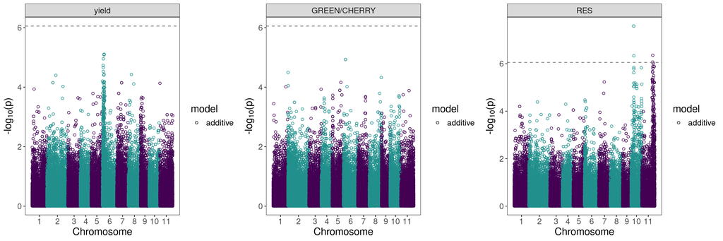

```r
p1 <- manhattan.plot(data2,traits="yield", models="additive")
p2 <- manhattan.plot(data2,traits="GREEN/CHERRY", models="additive")
p3 <- manhattan.plot(data2,traits="RES", models="additive")

grid.arrange(p1,p2,p3,ncol=3)
```

### Genetic Architecture

By understanding the genetic architecture, we need to answer:

- How many genes/QTL ? `getQTL`
- Where are the genes/QTL in the genome? `getQTL`
- What is the effect on the phenotype (positive or negative)? `getQTL`
- What is the gene action (dominant? additive?) ? `getQTL`
- How much of the phenotypic variance is explained by each marker associated to the gene/QTL? `fit.QTL`
- What is the polymorphism?
- Is there any previous biological information?

```r
library(knitr)
library(GWASpoly)
load("/home/felipe/Dropbox (UFL)/classes/Molecular_Breeding/class5_GWAS/GWASmodels/coffee_gwaspoly.Rdata")
#data2 <- set.threshold(data.loco.scan,method="Bonferroni",level=0.05)
qtl <- get.QTL(data=data2,traits="RES",bp.window=5e6) # Why this bp.window? Next tutorial !
knitr::kable(qtl)
```

|  | Trait | Model | Threshold | Marker | Chrom | Position | Ref | Alt | Score | Effect |
| --- | --- | --- | --- | --- | --- | --- | --- | --- | --- | --- |
| 9787 | RES | additive | 6.06 | 10_6651413 | 10 | 6651413 | 0 | 1 | 7.59 | -17.16705 |
| 13723 | RES | additive | 6.06 | 11_28261291 | 11 | 28261291 | 0 | 1 | 6.36 | -17.61558 |

**Proportion of the phenotypic variance**

- R2 statistic: coefficient of determination, is one of the most frequently used measures of prediction power and goodness-of-fit for simple linear regression models. R2 -like statistics complement statistical testing by providing practitioners with a more intuitive measurement than the P-value from other statistical tests.
- [GEMMA author](https://github.com/genetics-statistics/GEMMA/issues/31) suggested to take a look on the ratio between vg and ve for the alternative model (l_remle=vg/ve) reported in the `l_remle` collumn.
- Formula 1 presented [here](https://onlinelibrary.wiley.com/doi/full/10.1111/mec.12968) : $(\beta^2 \times var(x))/var(y)$, where var(x) is the variance of the genotype at the focal SNPs, and var (y) is the variance of the phenotype. $\beta$ is reported for each SNP in the LMM output.
- Formula 2 presented [here](https://github.com/genetics-statistics/GEMMA/issues/12): `pve <- var(x) * (beta^2 + se^2)/var(y)`
- Formula 3 presented [here](https://www.frontiersin.org/articles/10.3389/fgene.2018.00217/full) as: $V_g = 100 \times \dfrac{2pq\beta^2}{\sigma^2_a}$, where, p and q are the allele frequencies for a given trait, $\beta$ is the additive effects of the SNPs, and $\sigma^2_a$ is the additive genetic variance for a trait

**`GWASpoly` approach using the RES trait**

- `GWASpoly` use a multiple QTL model approach and estimate the partial R2 for each QTL based on backward elimination.
- Backward Regression:
  - Specify a full model with all QTL
  - Each step gradually eliminates variables (ie., QTL) from the regression model using a given method (ex: AIC, p-value or other)
  - Find a reduced model that best explains the data

```r
# Additive
qtl1 <- get.QTL(data=data2,traits="RES",bp.window=5e6, model="additive")
fit.ans <- fit.QTL(data=data2,trait="RES", qtl=qtl1[,c("Marker","Model")])
fit.ans
```

```
##            Marker Chrom Position    Model         R2         pval
## 9787   10_6651413    10  6651413 additive 0.08024135 2.040896e-05
## 13723 11_28261291    11 28261291 additive 0.05866104 2.924592e-04
```

**Graphical representation**

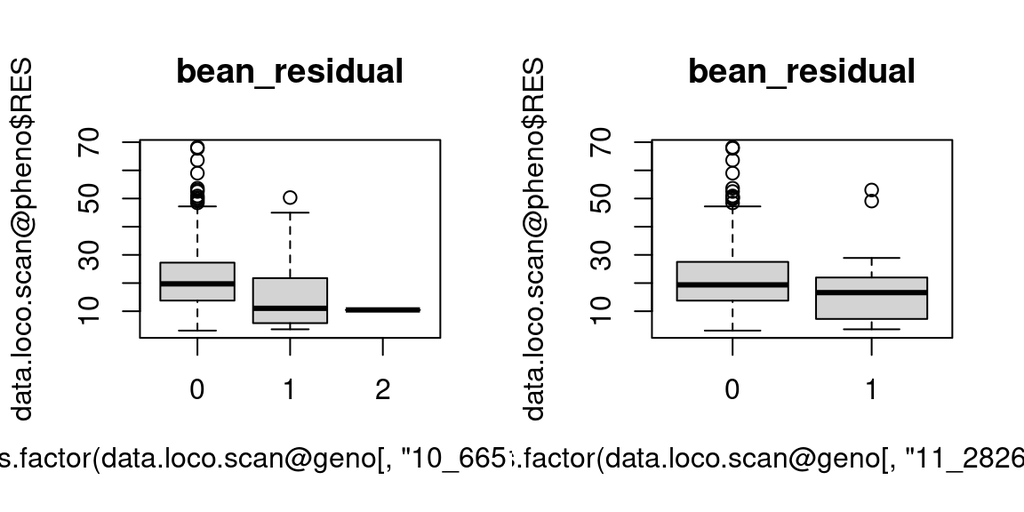

```r
par(mfrow=c(1,2))
boxplot(data.loco.scan@pheno$RES ~ as.factor(data.loco.scan@geno[,"10_6651413"]), main= "bean_residual")
boxplot(data.loco.scan@pheno$RES ~ as.factor(data.loco.scan@geno[,"11_28261291"]), main= "bean_residual")
```

## BLINK

- `GAPIT` R package
- [Github page](https://github.com/jiabowang/GAPIT)
- Software output multiple information

### Running it

- Same phenotypic file from `GWASpoly`
- Genotypic data similar to the input required by the `GWASpoly` package
- We will run only the BLINK model

```r
library(GAPIT)
# Phenotypic data
myY=read.csv("/home/felipe/Dropbox (UFL)/classes/Molecular_Breeding/class5_GWAS/GWASmodels/phenotype.csv")
tmp = read.csv("/home/felipe/Dropbox (UFL)/classes/Molecular_Breeding/class5_GWAS/GWASmodels/geno.csv")

# Genomic Data
a1 =tmp[,-c(1:3)]
a2 = t(a1)
myG = data.frame(rownames(a2),a2)
colnames(myG) = c("taxa",tmp$snp.name)
rownames(myG) <- NULL
myG[1:5,1:5]

# Imputing missing data
library(AGHmatrix)
myG.imputed = Mcheck(myG[,-1],thresh.maf = 0.01,
                     missingValue = NA,
                     impute.method = "mean")

myG.imputed1 = data.frame(myG[,1],myG.imputed,check.names = F)

# Mapping information
chr = as.numeric(unlist(lapply(strsplit(colnames(myG.imputed), "_"), function(x)x[1])))
pos = as.numeric(unlist(lapply(strsplit(colnames(myG.imputed), "_"), function(x)x[2])))
myGM = data.frame(SNP.name =colnames(myG.imputed),
                  chr = chr,
                  pos=pos)

# Running the package
myGAPIT = GAPIT(Y = myY,
                GD=myG.imputed1,
                GM=myGM,
                PCA.total = 5,
                model="Blink",
                SNP.MAF = 0.01)
```

### Manhattan Plots

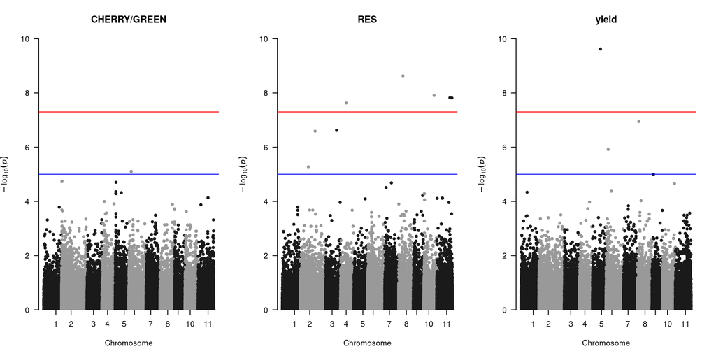

```r
library(qqman)
setwd("/home/felipe/Dropbox (UFL)/classes/Molecular_Breeding/class5_GWAS/GWASmodels/GAPIT_output")

# List all files with "PVE" in the name
results_files <- list.files(pattern = "Results.*NYC|NYC.*Results")

# Read all matching files into a named list of data frames
pvalues_tables <- lapply(results_files, read.csv, header = TRUE)

# Plots
df1 = data.frame(SNP = pvalues_tables[[1]]$SNP,
                CHR = pvalues_tables[[1]]$Chr,
                BP = pvalues_tables[[1]]$Pos,
                P = pvalues_tables[[1]]$P.value)
df2 = data.frame(SNP = pvalues_tables[[2]]$SNP,
                CHR = pvalues_tables[[2]]$Chr,
                BP = pvalues_tables[[2]]$Pos,
                P = pvalues_tables[[2]]$P.value)
df3 = data.frame(SNP = pvalues_tables[[3]]$SNP,
                CHR = pvalues_tables[[3]]$Chr,
                BP = pvalues_tables[[3]]$Pos,
                P = pvalues_tables[[3]]$P.value)

par(mfrow=c(1,3))
manhattan(df1, main="CHERRY/GREEN",ylim=c(0,10))
manhattan(df2, main="RES",ylim=c(0,10))
manhattan(df3, main="yield",ylim=c(0,10))
```

**Question**

- Compare the significant markers identified for the `RES` traits in the chr 10 and 11. Can we identify such hits in both methods?
- What about the hit in the chromosome 5 for yield ?

### Proportion of the Variance Explained (PVE)

$$\text{PVE}_{SNP} = \dfrac{2p_i(1-p_i)
\hat{\beta}_i}{\text{Var}(y)}$$

```r
setwd("/home/felipe/Dropbox (UFL)/classes/Molecular_Breeding/class5_GWAS/GWASmodels/GAPIT_output")

# List all files with "PVE" in the name
pve_files <- list.files(pattern = "PVE.*NYC|NYC.*PVE")

# Read all matching files into a named list of data frames
pve_tables <- lapply(pve_files, read.csv, header = TRUE)
names(pve_tables) <- tools::file_path_sans_ext(basename(pve_files))
pve_tables
```

```
## $`GAPIT.Association.PVE.BLINK.RES(NYC)`
##           SNP Chromosome Position      P.value MAF       nobs     effect
## 1  2_31738698          2 31738698 2.568247e-07 217   7.994425 0.04979519
## 2  3_23130832          3 23130832 2.395707e-07 217   3.832509 0.20843473
## 3  4_11843647          4 11843647 2.342673e-08 217   5.685535 0.24534479
## 4   8_9138553          8  9138553 2.346887e-09 217  -6.856254 0.11573910
## 5 10_21999015         10 21999015 1.249100e-08 217  13.679615 0.01693316
## 6 11_28224886         11 28224886 1.505636e-08 217 -14.342703 0.05299539
## 7 11_32479154         11 32479154 1.528609e-08 217  -4.076948 0.46744868
##   Phenotype_Variance_Explained...
## 1                    2.529667e+01
## 2                    1.239761e-02
## 3                    3.614017e-01
## 4                    2.080226e-07
## 5                    0.000000e+00
## 6                    0.000000e+00
## 7                    0.000000e+00
##
## $`GAPIT.Association.PVE.BLINK.yield(NYC)`
##          SNP Chromosome Position      P.value MAF       nobs    effect
## 1 5_17020928          5 17020928 2.383154e-10 222 -0.6437509 0.1036036
## 2  8_2985937          8  2985937 1.132759e-07 222  0.3931969 0.1824324
##   Phenotype_Variance_Explained...
## 1                      0.09991301
## 2                      0.00000000
```

**Questions**

- How to interpret p.value and PVE?
  - p.value= confidence
  - PVE= contribution

# Conclusion and final notes

There are several **differences and similarities** between the GWAS models. Here, we focused on two contrasting methods (LMM and BLINK) and noticed some trends.

1. **Detection of Major-Effect Markers** Both models are generally effective at identifying markers with **large genetic effects**. For example, when analyzing the **RES trait**, which is likely influenced by one or a few major loci, both LMM and BLINK captured the hits. This suggests that when effect sizes are strong, the choice of model may have less impact on detection power.
2. **Signal Structure and LD Handling** A visual difference appears in how the results are **visualized and interpreted**. The **LMM** often produces a **tower-like structure** in the Manhattan plot, characterized by **multiple neighboring SNPs showing similar significance**, due to **linkage disequilibrium (LD)** around the causal variant. In contrast, **BLINK** tends to produce a **clear, unique peak**, representing a single most informative SNP. This is a direct result of BLINK’s **iterative model selection** strategy and its explicit **use of LD to avoid redundancy** among SNPs. By accounting for LD and adding SNPs stepwise based on Bayesian Information Criterion (BIC), BLINK isolates the most representative markers while excluding those with redundant signals.
3. **Power and False Positive Control** **LMM is known for its conservative nature**—it effectively controls false positives by modeling population structure and relatedness. However, this can lead to a loss of power, particularly when trying to detect **small or moderate-effect loci**, on the other hand, BLINK can leverage its **detection power**, especially for **small-effect markers**.

# References

- Kang, H. M., Zaitlen, N. A., Wade, C. M., Kirby, A., Heckerman, D., Daly, M. J., & Eskin, E. (2008). Efficient control of population structure in model organism association mapping. *Genetics*, 178(3), 1709–1723. https://doi.org/10.1534/genetics.107.080101
- Zhou, X., & Stephens, M. (2012). Genome-wide efficient mixed-model analysis for association studies. *Nature Genetics*, 44, 821–824. https://doi.org/10.1038/ng.2310
- Price, A. L., Patterson, N. J., Plenge, R. M., Weinblatt, M. E., Shadick, N. A., & Reich, D. (2006). Principal components analysis corrects for stratification in genome-wide association studies. *Nature Genetics*, 38, 904–909.
- Purcell, S., Neale, B., Todd‐Brown, K., Thomas, L., Ferreira, M. A. R., Bender, D., … & Sham, P. C. (2007). PLINK: a toolset for whole-genome association and population-based linkage analyses. *PLoS Genetics*, 3(3), e000000, e.g. 1‑16.
- Segura, V., Vilhjálmsson, B., Platt, A., Korte, A., Seren, Ü., Long, Q., & Nordborg, M. (2012). An efficient multi-locus mixed-model approach for genome-wide association studies in structured populations. *Nature Genetics*
- Liu, X., Huang, M., Fan, B., Buckler, E. S., & Zhang, Z. (2016). Iterative usage of fixed and random effect models for powerful and efficient genome-wide association studies. *PLoS Genetics*, 12(2), e1005767. https://doi.org/10.1371/journal.pgen.1005767
- Huang, M., Liu, X., Zhou, Y., Summers, R. M., & Zhang, Z. (2018). BLINK: a package for the next level of genome-wide association studies with both individuals and markers in the millions. *GigaScience*, 8(2), giy154. https://doi.org/10.1093/gigascience/giy154
- Ferrão, L. F. V., Riva-Souza, E. M., & Munoz, P. R. (2024). Genomic-assisted breeding for climate-smart coffee. The Plant Genome, 17(1), e20321. [Link](https://doi.org/10.1002/tpg2.20321)